# Data Visualization with ggplot2

## Complex Geoms

### Reference

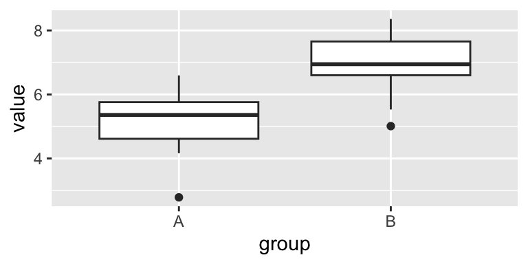

`geom_boxplot`

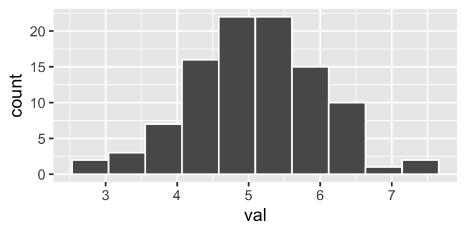

`geom_histogram`

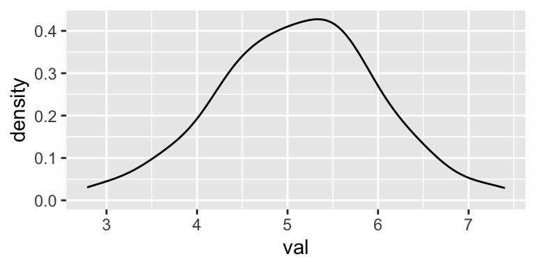

`geom_density`

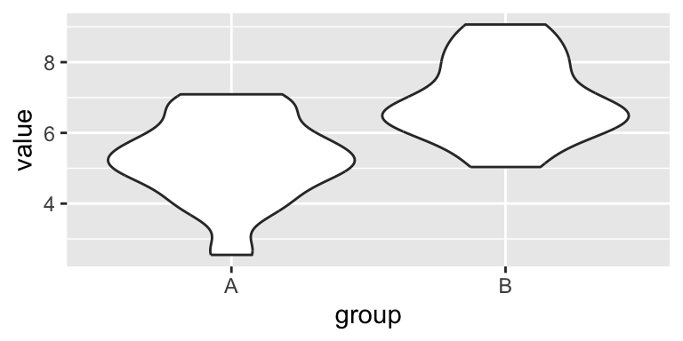

`geom_violin`

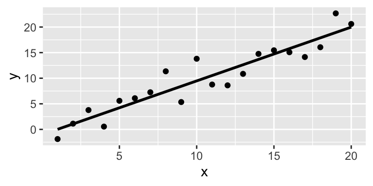

`geom_smooth`

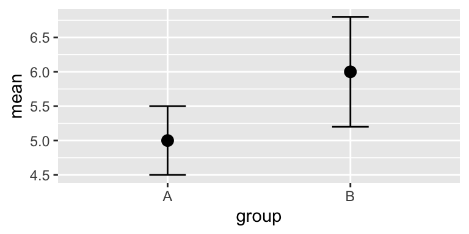

`geom_errorbar`

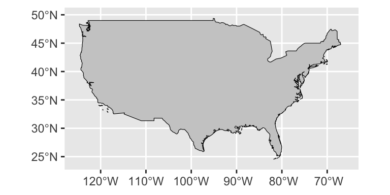

`geom_sf`

| geom | Use for |
| --- | --- |
| `geom_boxplot()`. | Compare distributions across groups |
| `geom_histogram()` | Distribution of a single continuous variable (frequency bins) |
| `geom_density()` | Smoothed distribution of a single continuous variable |
| `geom_violin()` | Visualizing distributions across categories (shape of data, not just box) |
| `geom_smooth()` | Adding fitted trend/smoothed lines (LOESS, GAM, linear, etc.) |
| `geom_errorbar()` | Showing uncertainty or variability (e.g., CI ranges around a mean) |
| `geom_sf()` | Plotting spatial (map) data stored as `sf` objects |

## Complex Geoms

### `geom_boxplot`

Suppose we surveyed people about their trust in government on a 1–10 scale (1 = no trust, 10 = complete trust). We want to compare typical values and how spread out the answers are for men and women.

```r
set.seed(123)

# Toy survey dataset
eg4 <- data.frame(
  gender = rep(c("Men", "Women"), each = 20),
  trust = c(
    rnorm(20, mean = 5, sd = 2),
    rnorm(20, mean = 8, sd = 1)))
```

## Complex Geoms

### `geom_boxplot`

Suppose we surveyed people about their trust in government on a 1–10 scale (1 = no trust, 10 = complete trust). We want to see the typical values and how spread out the answers are.

| gender | trust |
| --- | --- |
| Men | 3.879049 |
| Men | 4.539645 |
| Men | 8.117417 |
| Men | 5.141017 |
| Men | 5.258576 |
| Men | 8.430130 |

## Complex Geoms

### `geom_boxplot`

Suppose we surveyed people about their trust in government on a 1–10 scale (1 = no trust, 10 = complete trust). We want to see the typical values and how spread out the answers are.

```r
# Drawing the boxplot
ggplot(eg4, aes(y = trust)) +
  geom_boxplot()
```

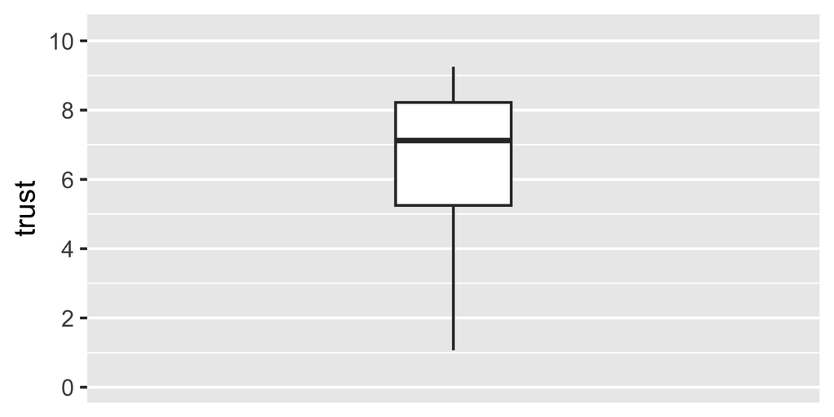

## Complex Geoms

### `geom_boxplot`

Suppose we surveyed people about their trust in government on a 1–10 scale (1 = no trust, 10 = complete trust). We want to see the typical values and how spread out the answers are.

```r
ggplot(eg4, aes(y = trust)) +
  geom_boxplot()
```

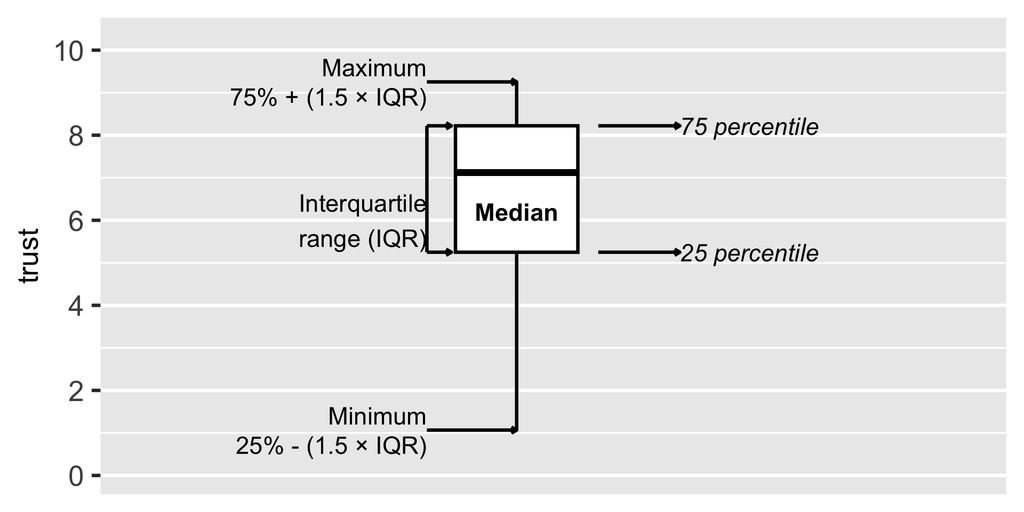

## Complex Geoms

### `geom_boxplot`

Suppose we surveyed people about their trust in government on a 1–10 scale (1 = no trust, 10 = complete trust). We want to compare typical values and how spread out the answers are for men and women.

```r
set.seed(123)

# Toy survey dataset
eg5 <- data.frame(
  gender = rep(c("Men", "Women"), each = 20),
  trust = c(
    rnorm(20, mean = 5, sd = 2),
    rnorm(20, mean = 8, sd = 1)))
```

## Complex Geoms

### `geom_boxplot`

Suppose we surveyed people about their trust in government on a 1–10 scale (1 = no trust, 10 = complete trust). We want to compare typical values and how spread out the answers are for men and women.

| gender | trust |
| --- | --- |
| Men | 3.879049 |
| Men | 4.539645 |
| Men | 8.117417 |
| Men | 5.141017 |
| Men | 5.258576 |
| Men | 8.430130 |
| Men | 5.921832 |
| Men | 2.469877 |

## Complex Geoms

### `geom_boxplot`

Suppose we surveyed people about their trust in government on a 1–10 scale (1 = no trust, 10 = complete trust). We want to compare typical values and how spread out the answers are for men and women.

```r
ggplot(eg5, aes(x = gender, y = trust)) +
  geom_boxplot()
```

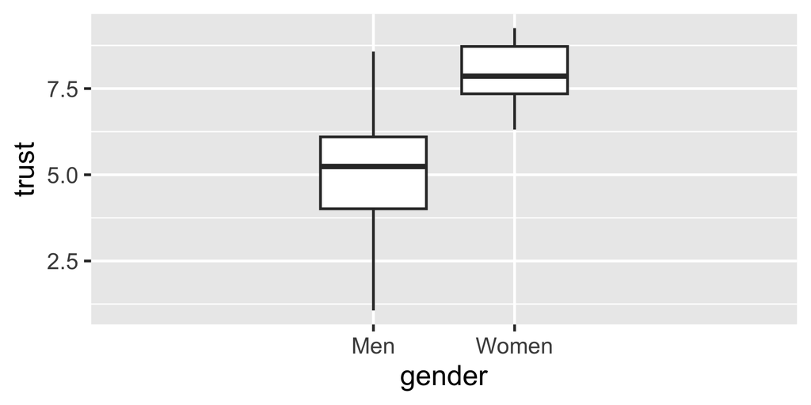

## Complex Geoms

### `geom_boxplot`

Suppose we surveyed people about their trust in government on a 1–10 scale (1 = no trust, 10 = complete trust). We want to compare typical values and how spread out the answers are for men and women.

```r
ggplot(eg5, aes(x = gender, y = trust)) +
  geom_boxplot()
```

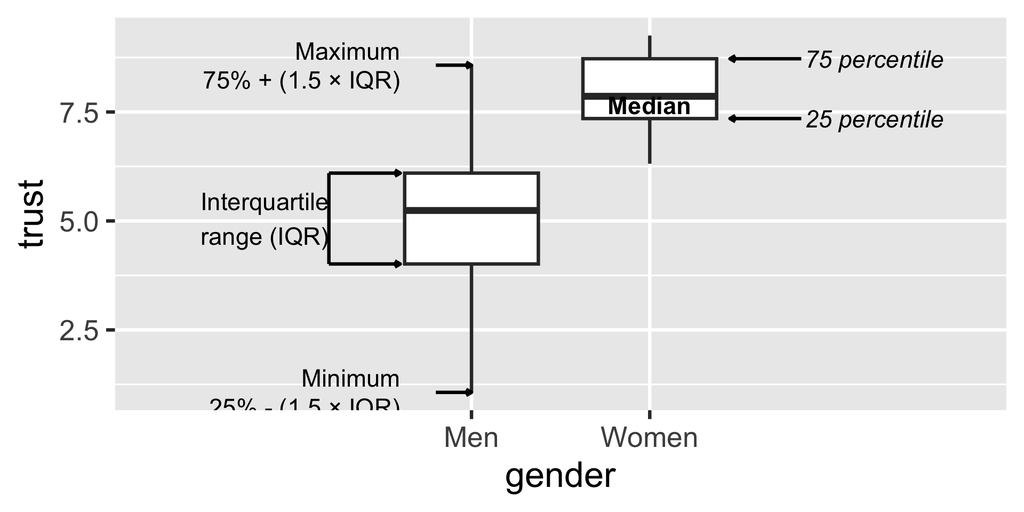

## Complex Geoms

### `geom_histogram`: What is a Histogram?

Histograms allow us to better understand how frequently or infrequently certain values occur in our dataset.

Imagine a set of values that are spaced out along a number line.

[figure not shown]

## Complex Geoms

### `geom_histogram`: What is a Histogram?

To construct a histogram, a section of the number line is divided into equal chunks, called bins.

Next, count how many data points sit inside each bin, and draw bars, one for each bin

The heights of the bars correspond to the number of data points.

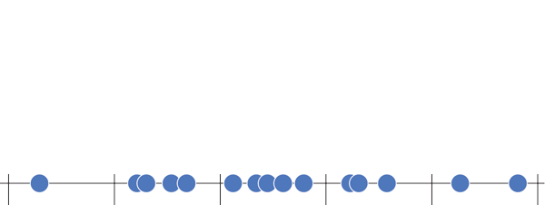

## Complex Geoms

### `geom_histogram`: What is a Histogram?

Draw in a y-axis which counts the number of data points in each bin

Finally label your bins.

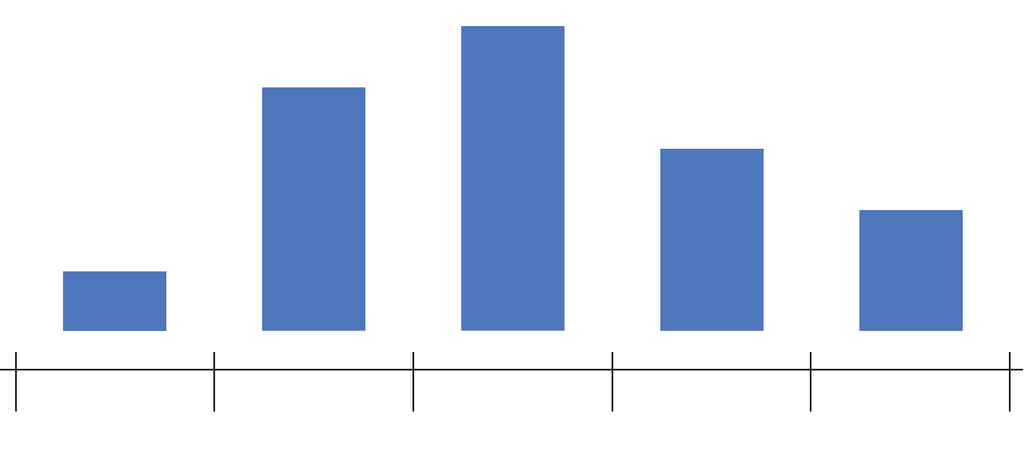

## Complex Geoms

### `geom_histogram`: Example

Suppose we surveyed people about their trust in government on a 1–10 scale (1 = no trust, 10 = complete trust). We want to compare typical values and how spread out the answers are.

```r
# Drawing the Histogram
ggplot(eg5, aes(x = trust)) +
  geom_histogram(bins = 10, color = "white")+
  coord_cartesian(xlim = c(2, 8))
```

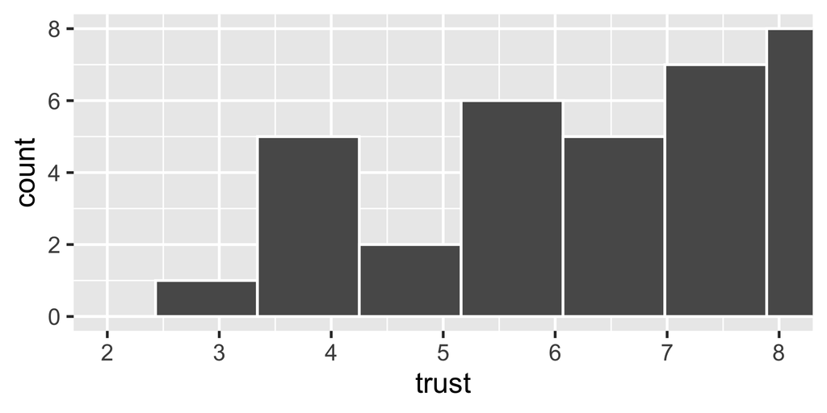

## Complex Geoms

### `geom_histogram`: Example

Suppose we surveyed people about their trust in government on a 1–10 scale (1 = no trust, 10 = complete trust). We want to compare typical values and how spread out the answers are.

There is a direct connection between histograms and boxplots:

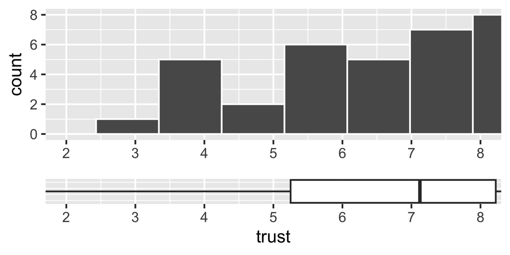

## Complex Geoms

### `geom_histogram`: Example

Suppose we surveyed people about their trust in government on a 1–10 scale (1 = no trust, 10 = complete trust). We want to compare typical values and how spread out the answers are.

There is a direct connection between histograms and boxplots:

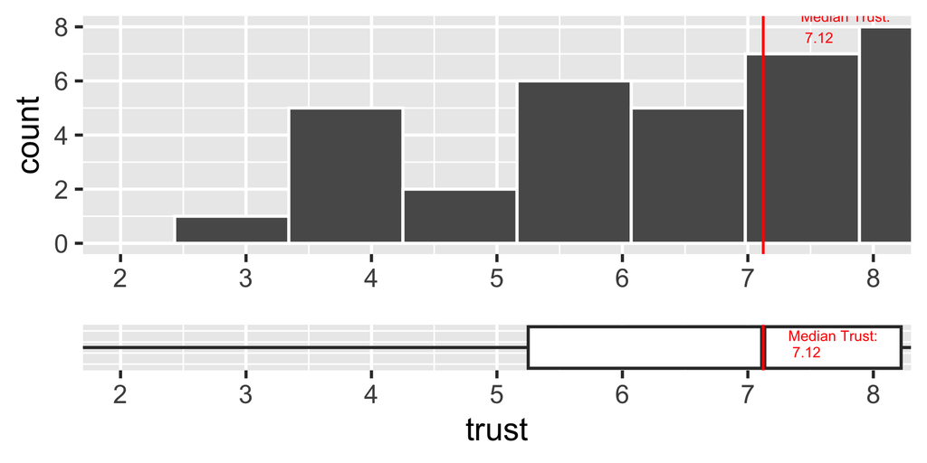

## Complex Geoms

### `geom_histogram`: Example

One specific aspect pertaining to histograms is the number of bins:

- too wide bins hide structure;
- too narrow bins are noisy..

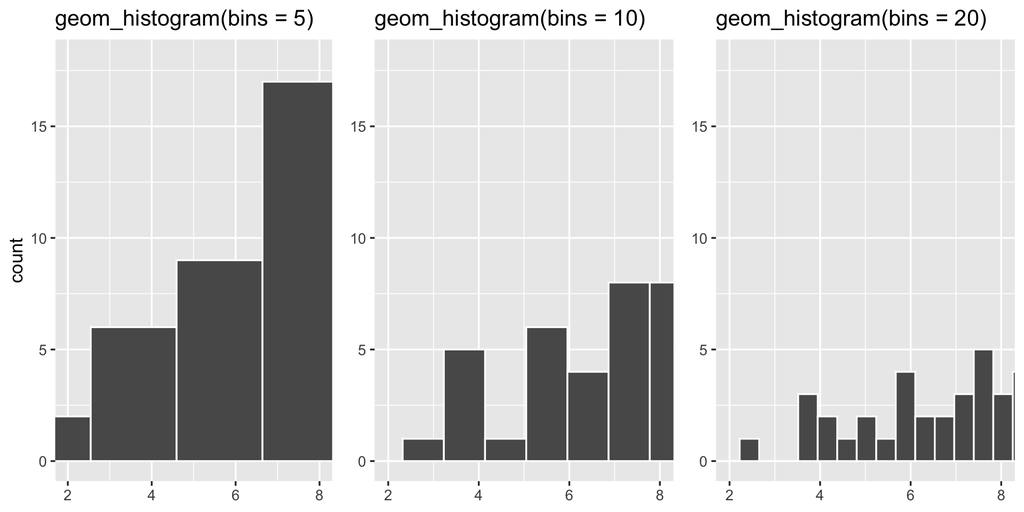

## Complex Geoms

### `geom_density`: What is a Density Curve?

A histogram counts how many students fall in each trust “bucket.”

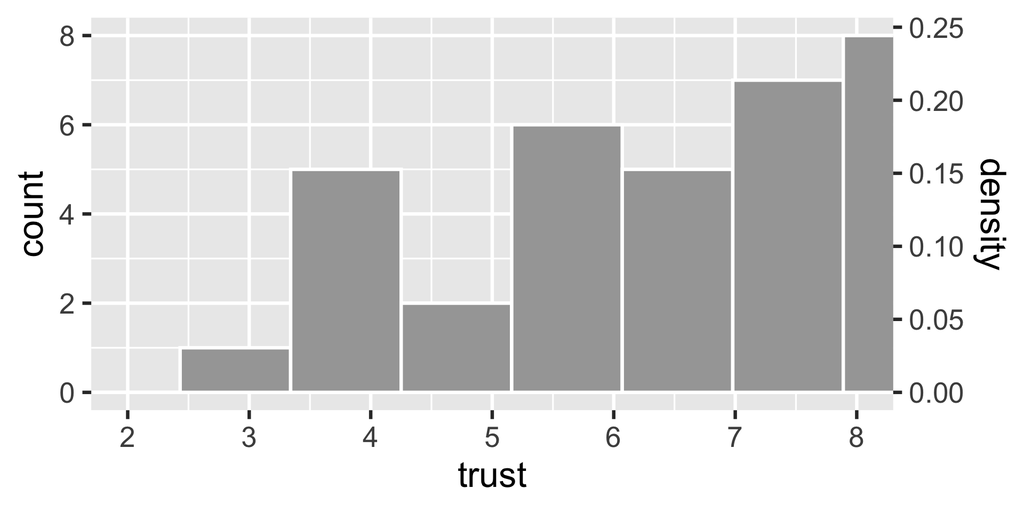

## Complex Geoms

### `geom_density`: What is a Density Curve?

A histogram counts how many students fall in each trust “bucket.”

A density curve smooths those buckets into a single curve so we see the overall shape.

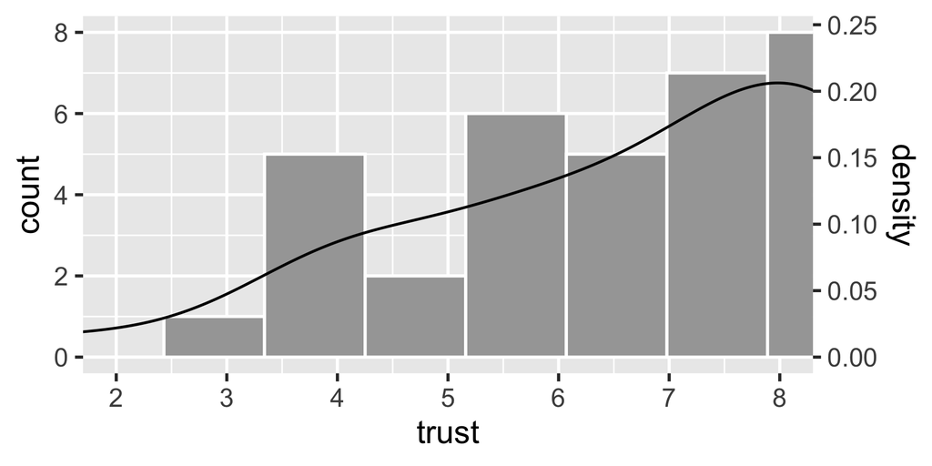

## Complex Geoms

### `geom_density`: What is a Density Curve?

A histogram counts how many students fall in each trust “bucket.”

A density curve smooths those buckets into a single curve so we see the overall shape.

The area under the entire curve = 1 (i.e., 100% of people).

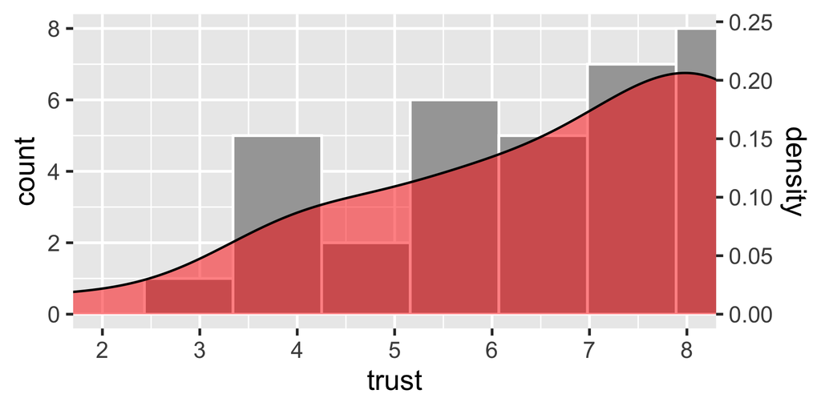

## Complex Geoms

### `geom_density`: What is a Density Curve?

A histogram counts how many students fall in each trust “bucket.”

A density curve smooths those buckets into a single curve so we see the overall shape.

The area under the entire curve = 1 (i.e., 100% of people).

The probability that a randomly chosen person’s trust score is between certain values (e.g. 5 and 7)

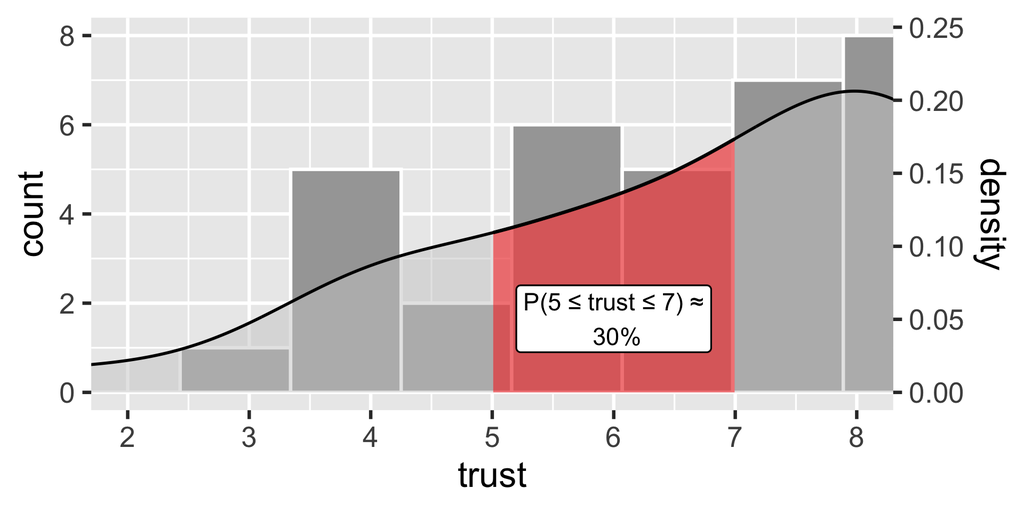

## Complex Geoms

### `geom_density`: What is a Density Curve?

A histogram counts how many students fall in each trust “bucket.”

A density curve smooths those buckets into a single curve so we see the overall shape.

The area under the entire curve = 1 (i.e., 100% of people).

The probability that a randomly chosen person’s trust score is above 5.

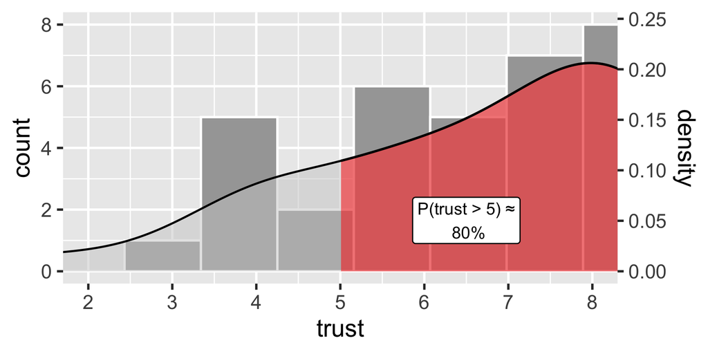

## Complex Geoms

### `geom_density`: What is a Density Curve?

A histogram counts how many students fall in each trust “bucket.”

A density curve smooths those buckets into a single curve so we see the overall shape.

The area under the entire curve = 1 (i.e., 100% of people).

The probability that a randomly chosen person’s trust score is below 4.

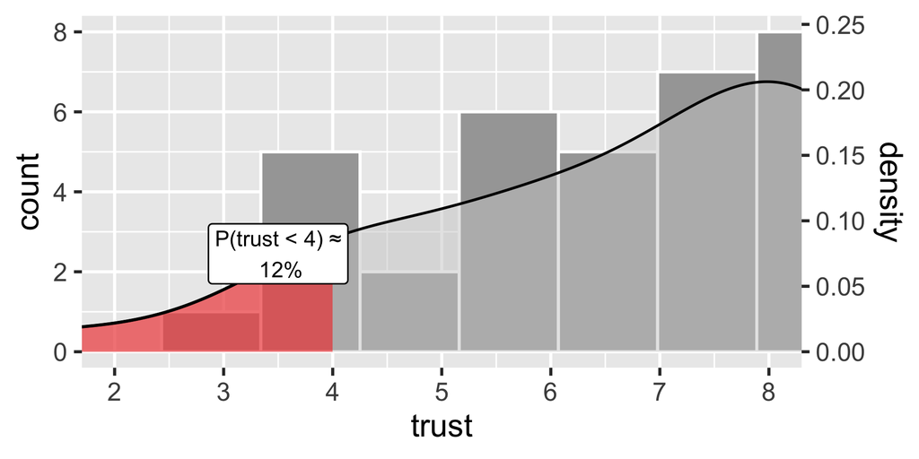

## Complex Geoms

### `geom_density`: What is a Density Curve?

Heights tell you nothing by themselves—areas tell you the share.

When I widen the range, the area grows—so the probability grows.

This curve is smoothed from the histogram; bandwidth controls how smooth.

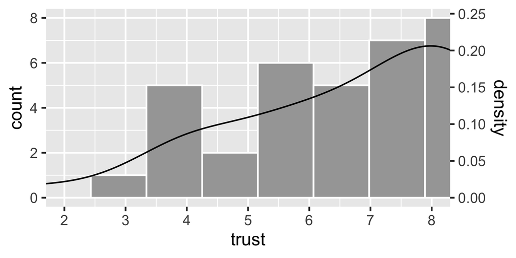

## Complex Geoms

### `geom_density`: What is a Density Curve?

Heights tell you nothing by themselves—areas tell you the share.

When I widen the range, the area grows—so the probability grows.

This curve is smoothed from the histogram; bandwidth controls how smooth.

Here too there is a connection between density, histograms, and boxplots.

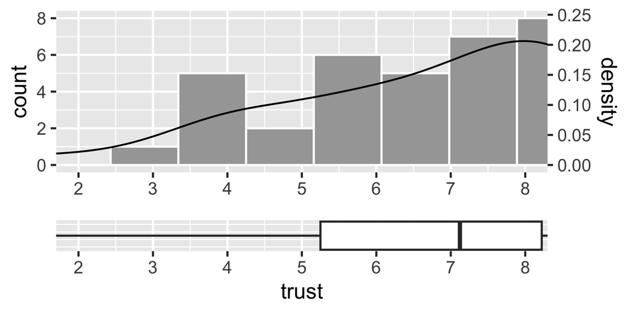

## Complex Geoms

### `geom_density`: Example

Suppose we surveyed people about their trust in government on a 1–10 scale (1 = no trust, 10 = complete trust). We want to compare typical values and how spread out the answers are.

```r
# Match density to histogram counts
N <- nrow(eg5)
binwidth <- diff(range(eg5$trust)) / 10  # because bins = 10

# Draw histogram
ggplot(eg5, aes(x = trust)) +
  geom_density(aes(y = after_stat(density) * N * binwidth), linewidth = 1) +
  labs(
    x = "trust",
    y = "count")
```

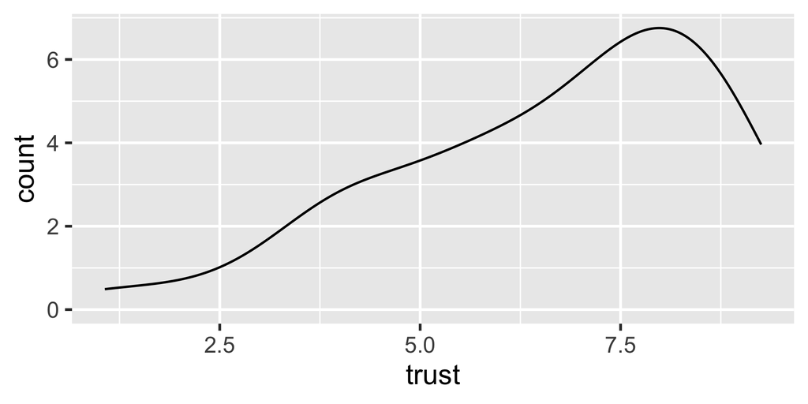

## Complex Geoms

### `geom_density`: Example

Suppose we surveyed people about their trust in government on a 1–10 scale (1 = no trust, 10 = complete trust). We want to compare typical values and how spread out the answers are.

It is more informative to include both `geom_density` and `geom_histogram`.

```r
# Match density to histogram counts
N <- nrow(eg5)
binwidth <- diff(range(eg5$trust)) / 10  # because bins = 10

# Draw histogram
ggplot(eg5, aes(x = trust)) +
  geom_histogram(bins = 10, color = "white") +
  geom_density(aes(y = after_stat(density) * N * binwidth), linewidth = 1) +
  labs(
    x = "trust",
    y = "count")
```

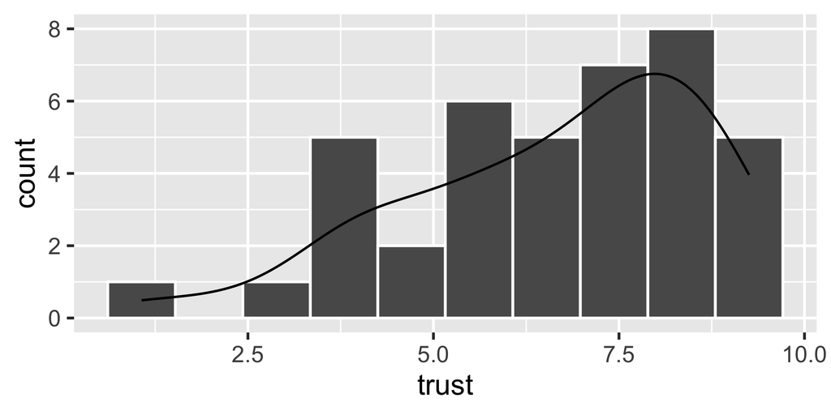

## Complex Geoms

### `geom_density`: Example

```r
# Match density to histogram counts
N <- nrow(eg5)
binwidth <- diff(range(eg5$trust)) / 10  # because bins = 10

# Draw histogram
ggplot(eg5, aes(x = trust)) +
  geom_histogram(bins = 10, color = "white") +
  geom_density(aes(y = after_stat(density) * N * binwidth), linewidth = 1) +
  labs(
    x = "trust",
    y = "count")
```

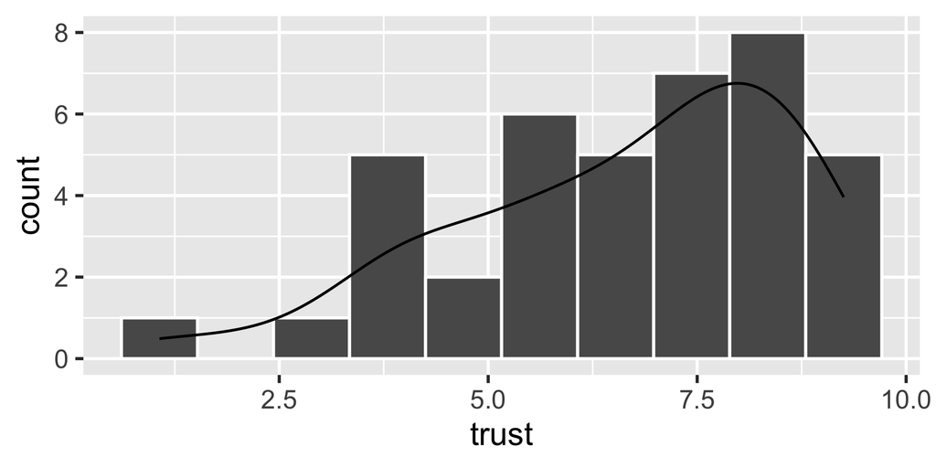

## Complex Geoms

### `geom_violin`: Example

Violin plots are symmetric representations of `geom_density`

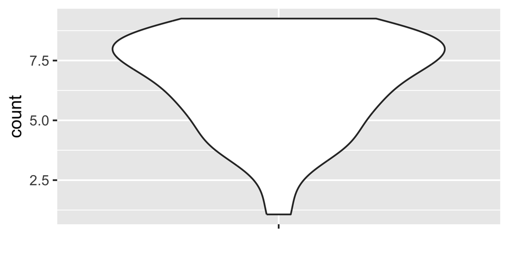

## Complex Geoms

### `geom_violin`: Example

Violin plots are symmetric representations of `geom_density`

This was our density

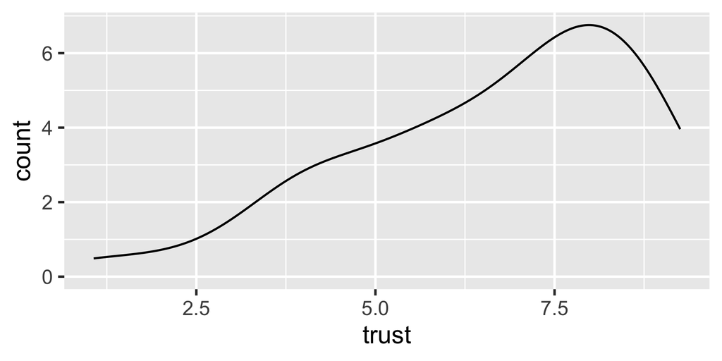

## Complex Geoms

### `geom_violin`: Example

Violin plots are symmetric representations of `geom_density`

This was our density shaded in white

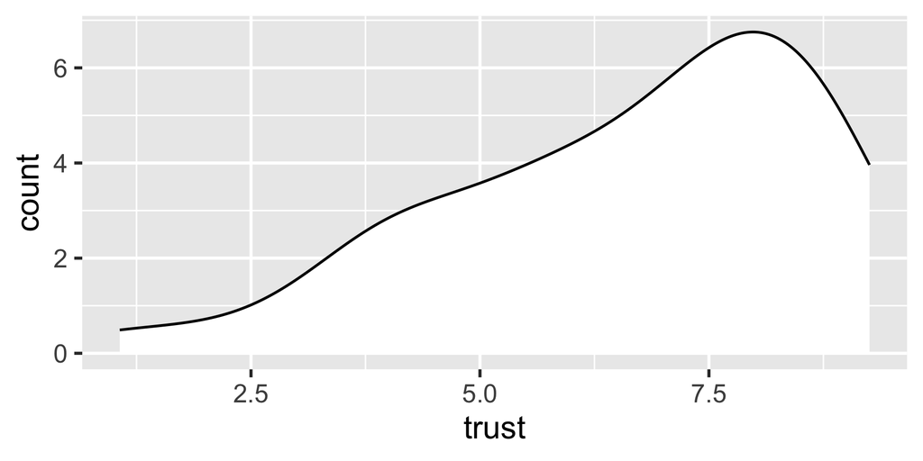

## Complex Geoms

### `geom_violin`: Example

Violin plots are symmetric representations of `geom_density`

This is our density flipped

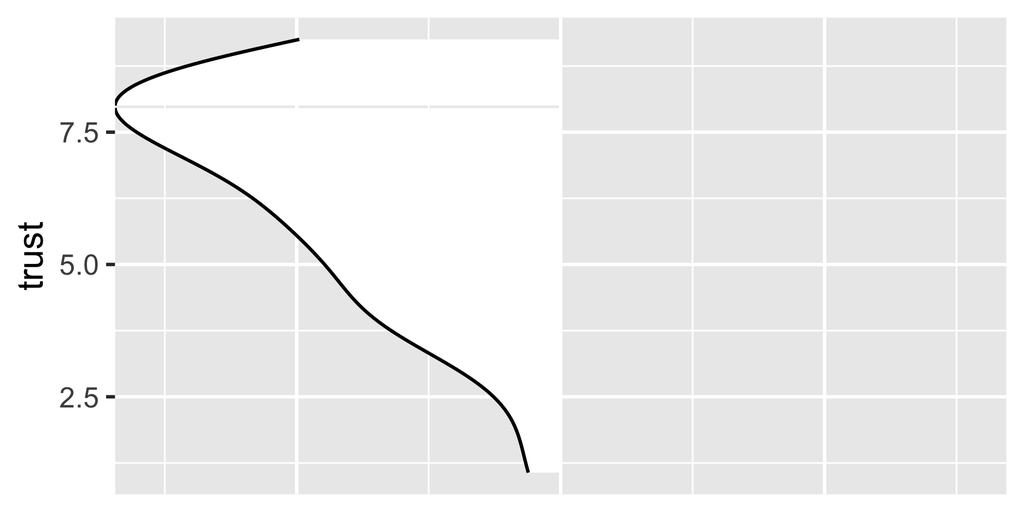

## Complex Geoms

### `geom_violin`: Example

Violin plots are symmetric representations of `geom_density`

This is what happens if we create a mirror density

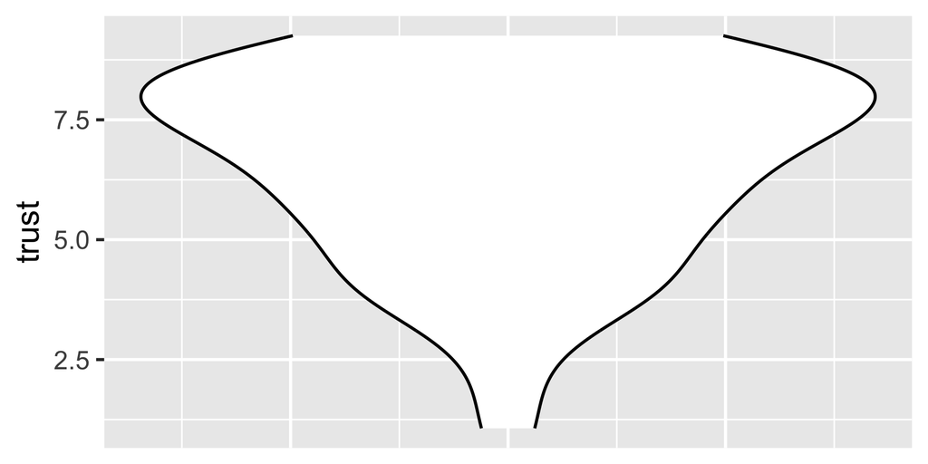

## Complex Geoms

### `geom_violin`: Example

Violin plots are symmetric representations of `geom_density`

This is what `geom_violin` looks like.

```r
ggplot(eg5, aes(x = "", y = trust)) +
  geom_violin()
```

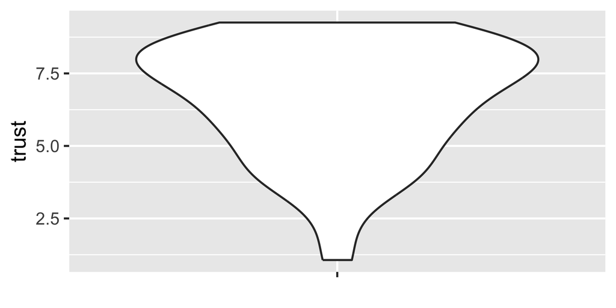

## Complex Geoms

### `geom_violin`: Example

Suppose we surveyed people about their trust in government on a 1–10 scale (1 = no trust, 10 = complete trust). We want to compare typical values and how spread out the answers are for men and women.

```r
ggplot(eg5, aes(x = gender, y = trust)) +
  geom_violin()
```

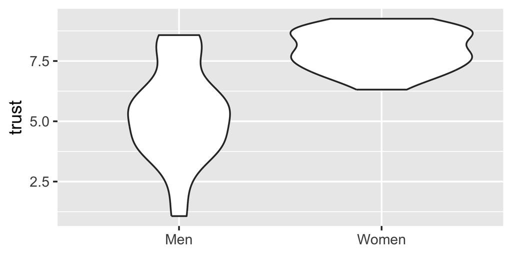

## Complex Geoms

### `geom_violin`: Example

**Interpretation**: The data suggests that men’s responses are more spread out (from low to high trust), while women’s are more concentrated in the middle-to-high range.

```r
ggplot(eg5, aes(x = gender, y = trust)) +
  geom_violin()
```

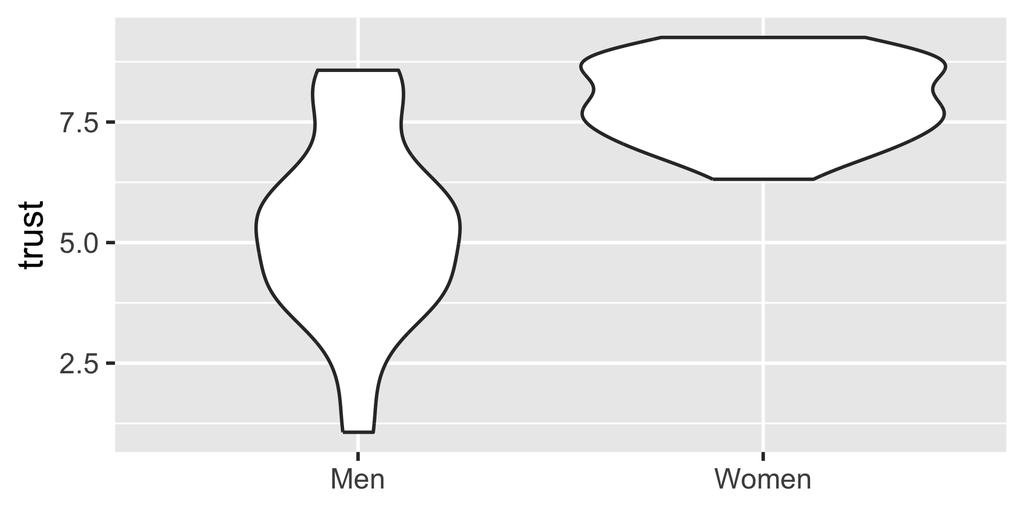

## Complex Geoms

### `geom_smooth`

This is what we had previously:

```r
# Example data
eg1 <- data.frame(
  democracy = c(-8, -7, -5, -3, 0, 2, 5, 8, 9),   # democracy score
  gdp = c(2, 9, 4, 7, 8, 20, 15, 25, 27),  # GDP per capita in $1000s
  country = c(
    "North Korea",   # very autocratic, very poor
    "Saudi Arabia",  # autocratic, but richer due to oil
    "Zimbabwe",      # authoritarian, low GDP
    "Russia",        # hybrid regime, middle income
    "Nigeria",       # similar position
    "India",         # low–mid democracy, growing GDP
    "Brazil",        # democracy, mid GDP
    "Poland",        # consolidated democracy, higher GDP
    "South Korea"   # rich democracy
  ))
```

## Complex Geoms

### `geom_smooth`

This is what we had previously:

| democracy | gdp | country |
| --- | --- | --- |
| -8 | 2 | North Korea |
| -7 | 9 | Saudi Arabia |
| -5 | 4 | Zimbabwe |
| -3 | 7 | Russia |
| 0 | 8 | Nigeria |
| 2 | 20 | India |
| 5 | 15 | Brazil |
| 8 | 25 | Poland |
| 9 | 27 | South Korea |

## Complex Geoms

### `geom_smooth`

This is what we had previously:

```r
# Scatterplot with geom_point
ggplot(eg1, aes(x = democracy, y = gdp)) +
  geom_point()
```

[output not shown]

## Complex Geoms

### `geom_smooth`

This is what happens when we try to fit a line:

```r
# Scatterplot with geom_point
ggplot(eg1, aes(x = democracy, y = gdp)) +
  geom_point()+
  geom_smooth(method = lm, se = FALSE, color="black")
```

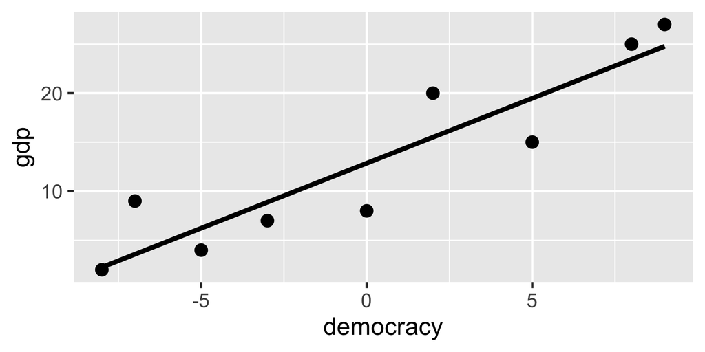

## Complex Geoms

### `geom_smooth`

**Interpretation**: As one moves right (more democratic), the dots usually sit higher—meaning those countries tend to be richer. The black line going up summarizes that big-picture pattern, even though a few dots don’t fit.

```r
# Scatterplot with geom_point
ggplot(eg1, aes(x = democracy, y = gdp)) +
  geom_smooth(method = lm, se = FALSE, color="black")
```

[figure not shown]

## Complex Geoms

### `geom_errorbar`

Error bars are like “antennae” on top of a mean.

They don’t show the full spread like a boxplot, but they give us a quick picture of how precise the average is.

- **Short bars** → data points are close together.
- **Long bars** → data points are spread out.

This is useful when we only want to compare averages.

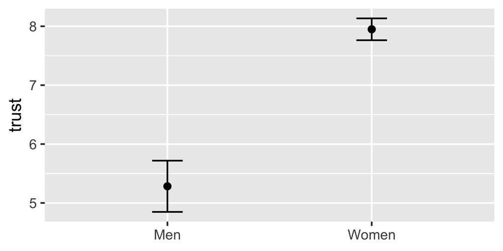

## Complex Geoms

### `geom_errorbar`

A natural question is how do error bars compare to boxplots.

**Boxplot**

- Shows the distribution of the data: Median, quartiles, and possible outliers.
- Good for: seeing the shape and spread

**Error Bar**

- Summarizes just the mean + uncertainty (often mean ± standard error or confidence interval).
- Doesn’t show the full shape of the data.

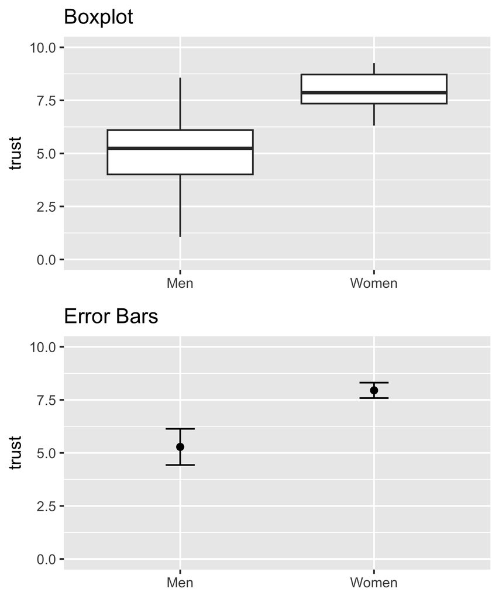

## Complex Geoms

### `geom_errorbar`

Suppose we surveyed people about their trust in government on a 1–10 scale (1 = no trust, 10 = complete trust). We want to compare typical values and how spread out the answers are for men and women.

```r
# Set a random seed so results are reproducible.
# (Without this, R will generate different random numbers each time.)
set.seed(123)

# -------------------------------------------------------------
# Step 1: Create a toy dataset: "trust in government" by gender
# --------------------------------------------------------------
eg5 <- data.frame(
  # Repeat the labels "Men" and "Women" 20 times each
  gender = rep(c("Men", "Women"), each = 20),

  # Generate 20 trust values for Men ~ Normal(mean=5, sd=2)
  # Generate 20 trust values for Women ~ Normal(mean=8, sd=1)
  trust = c(
    rnorm(20, mean = 5, sd = 2),
    rnorm(20, mean = 8, sd = 1)
  )
)
#Print the first 3 entries
head(eg5, n=3)
```

| gender | trust |
| --- | --- |
| Men | 3.879049 |
| Men | 4.539645 |
| Men | 8.117417 |

## Complex Geoms

### `geom_errorbar`

Suppose we surveyed people about their trust in government on a 1–10 scale (1 = no trust, 10 = complete trust). We want to compare typical values and how spread out the answers are for men and women.

```r
# ----------------------------------------------------------------------
# Step 2: Calculate mean trust and error bars (95% confidence intervals)
# ----------------------------------------------------------------------
df_err <- eg5 %>%
  group_by(gender) %>%       # Group data by gender
  summarise(
    mean = mean(trust),      # Average trust per gender
    se = sd(trust) / sqrt(n()), # Standard error = sd / sqrt(sample size)
  ) %>%
  mutate(
    # 95% confidence interval = mean ± 1.96 * standard error
    ymin = mean - 1.96 * se,   # Lower bound
    ymax = mean + 1.96 * se    # Upper bound
  )
head(df_err, n=3)
```

| gender | mean | se | ymin | ymax |
| --- | --- | --- | --- | --- |
| Men | 5.283248 | 0.4349892 | 4.430669 | 6.135826 |
| Women | 7.948743 | 0.1855799 | 7.585006 | 8.312480 |

## Complex Geoms

### `geom_errorbar`

Suppose we surveyed people about their trust in government on a 1–10 scale (1 = no trust, 10 = complete trust). We want to compare typical values and how spread out the answers are for men and women.

```r
# --------------------------------------------------------
# Step 3: Plotting the means with error bars using ggplot2
# --------------------------------------------------------
ggplot(df_err, aes(x = gender, y = mean)) +
  geom_point(size = 4) +  # Plot mean values as large points
  geom_errorbar(
    aes(ymin = ymin, ymax = ymax), # Add vertical error bars
    width = 0.15                   # Small horizontal "cap" on error bars
  ) +
  labs(
    x = NULL,                       # Remove x-axis label
    y = "trust",      # Label y-axis
    title = "Error Bars"            # Add plot title
  ) +
  coord_cartesian(ylim = c(0, 10))  # Set y-axis limits from 0 to 10
```

[output not shown]

## Complex Geoms

### `geom_errorbar`

Suppose we surveyed people about their trust in government on a 1–10 scale (1 = no trust, 10 = complete trust). We want to compare typical values and how spread out the answers are for men and women.

```r
set.seed(123)

#Step1: Toy dataset: trust in government by gender
eg5 <- data.frame(
  gender = rep(c("Men", "Women"), each = 20),
  trust = c(
    rnorm(20, mean = 5, sd = 2),
    rnorm(20, mean = 8, sd = 1)))

#Step2: Calculating Error bars
df_err <- eg5 %>%
  group_by(gender) %>%
  summarise(
    mean = mean(trust),
    se = sd(trust) / sqrt(n()),
  ) %>%
  mutate(
    ymin = mean - 1.96 * se,   # 95% CI lower bound
    ymax = mean + 1.96 * se    # 95% CI upper bound
  )

#Step3: Plotting
ggplot(df_err, aes(x = gender, y = mean)) +
  geom_point(size = 4) +
  geom_errorbar(aes(ymin = ymin, ymax = ymax), width = 0.15) +
  labs(
    x = NULL,
    y = "trust",
    title = "Error Bars"
  ) +
  coord_cartesian(ylim = c(0, 10))   # same y-axis
```

## Complex Geoms

### `geom_errorbar`

**Interpretation**: Women in this sample show higher average trust in government than men. The bars show our uncertainty, and since they don’t overlap much, it means the difference is likely real and not just due to chance.

```r
set.seed(123)

#Step1: Toy dataset: trust in government by gender
eg5 <- data.frame(
  gender = rep(c("Men", "Women"), each = 20),
  trust = c(
    rnorm(20, mean = 5, sd = 2),
    rnorm(20, mean = 8, sd = 1)))

#Step2: Calculating Error bars
df_err <- eg5 %>%
  group_by(gender) %>%
  summarise(
    mean = mean(trust),
    se = sd(trust) / sqrt(n()),
  ) %>%
  mutate(
    ymin = mean - 1.96 * se,   # 95% CI lower bound
    ymax = mean + 1.96 * se    # 95% CI upper bound
  )

#Step3: Plotting
ggplot(df_err, aes(x = gender, y = mean)) +
  geom_point(size = 4) +
  geom_errorbar(aes(ymin = ymin, ymax = ymax), width = 0.15) +
  labs(
    x = NULL,
    y = "trust",
    title = "Error Bars"
  ) +
  coord_cartesian(ylim = c(0, 10))   # same y-axis
```

## Complex Geoms

### `geom_sf`

`geom_sf` draws maps from sf objects (“simple features” = data + geometry).

It works like other geoms: points and lines

## Complex Geoms

### `geom_sf`

`geom_sf` draws maps from sf objects (“simple features” = data + geometry).

With `geom_sf`, you can map points (cities, places, settlements)

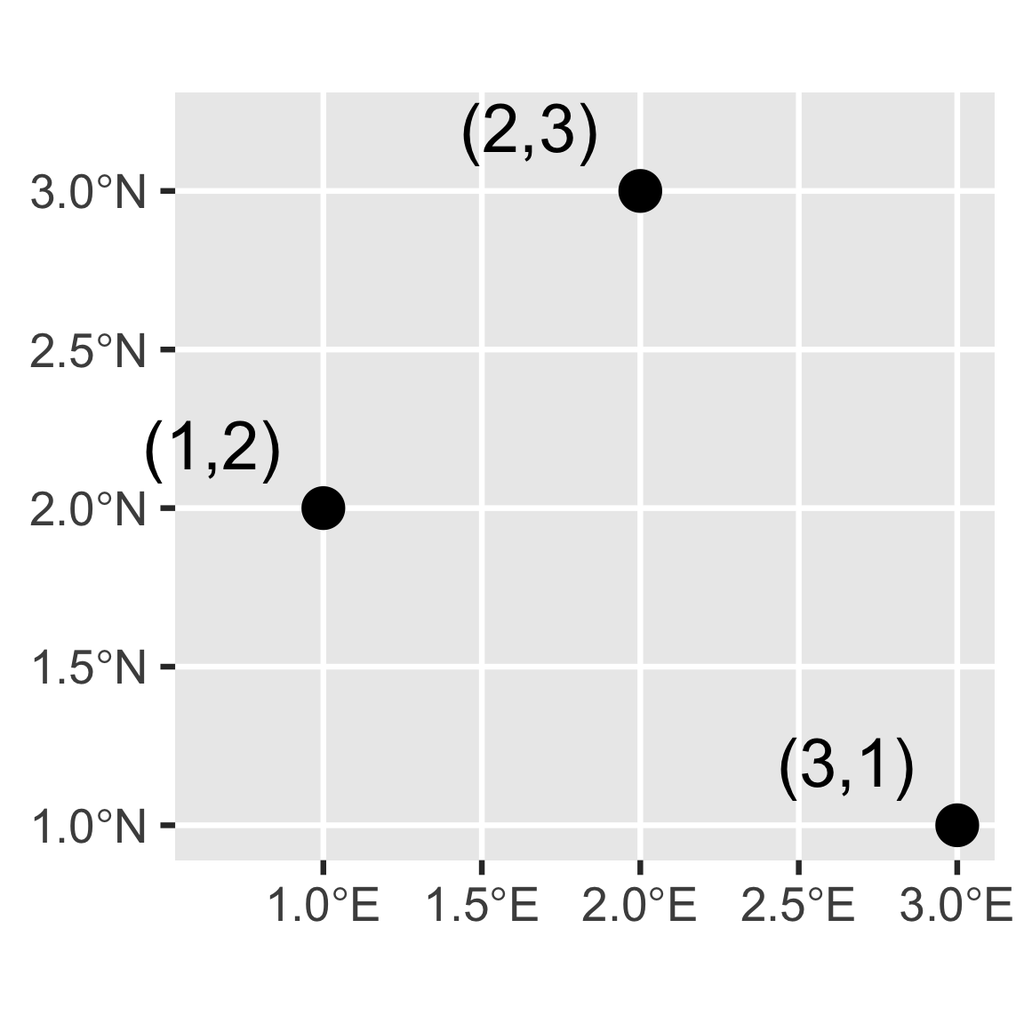

## Complex Geoms

### `geom_sf`

`geom_sf` draws maps from sf objects (“simple features” = data + geometry).

With `geom_sf`, you can map lines (rivers, roads, straight lines)

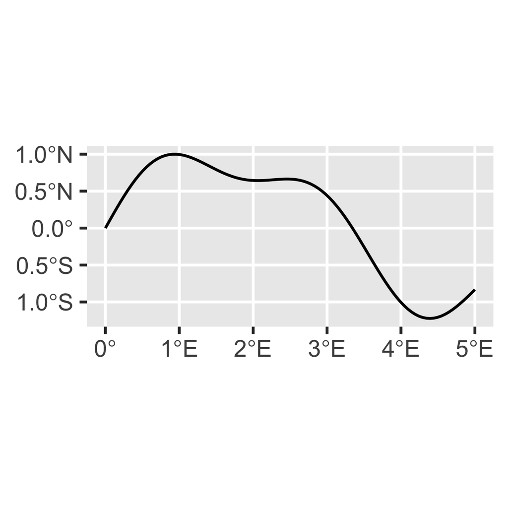

## Complex Geoms

### `geom_sf`

`geom_sf` draws maps from sf objects (“simple features” = data + geometry).

With `geom_sf`, you can map polygons (countries, parks, seas, etc.)

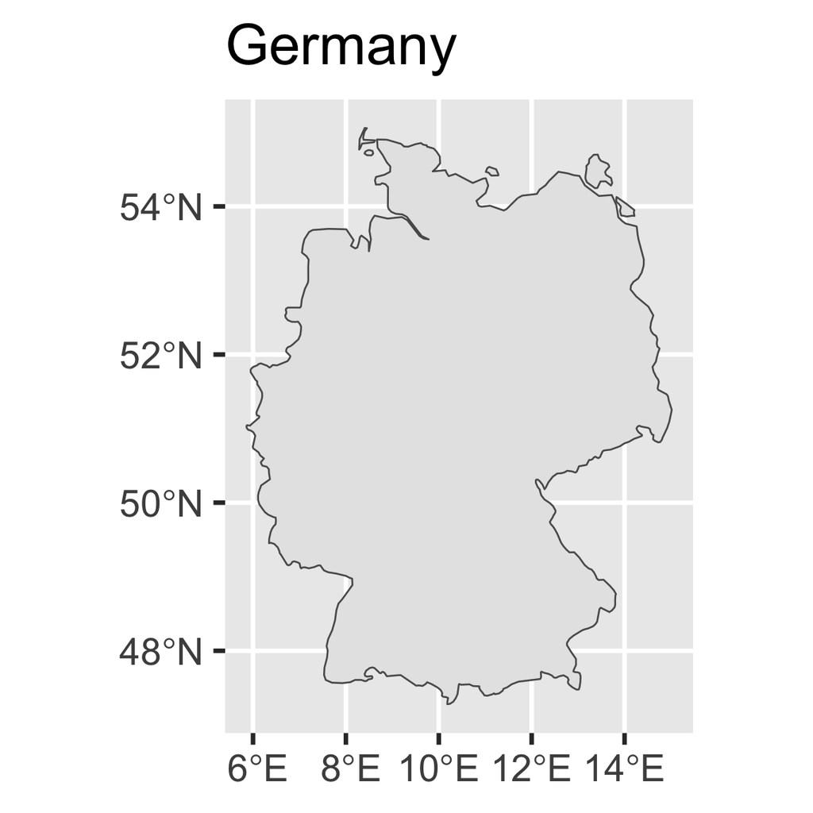

## Complex Geoms

### `geom_sf`

`geom_sf` draws maps from sf objects (“simple features” = data + geometry).

It works like other geoms: points and lines

Typical workflow:

- Get a shape (countries, regions, cities, rivers, roads, etc.)
- Plot them with `geom_sf`

## Complex Geoms

### `geom_sf` Example

```r
# Install once (uncomment if needed):
# install.packages(c("sf", "ggplot2", "rnaturalearth", "rnaturalearthdata"))
library(ggplot2)
library(sf)
library(rnaturalearth)
library(rnaturalearthdata)

# Step1: Get a country polygons dataset as an sf object
world <- rnaturalearth::ne_countries(scale = "medium",
                                     returnclass = "sf")
head(world, n=3)
```

| featurecla | scalerank | labelrank | sovereignt | sov_a3 | adm0_dif | level | type | tlc | admin | adm0_a3 | geou_dif | geounit | gu_a3 | su_dif | subunit | su_a3 | brk_diff | name | name_long | brk_a3 | brk_name | brk_group | abbrev | postal | formal_en | formal_fr | name_ciawf | note_adm0 | note_brk | … |
| --- | --- | --- | --- | --- | --- | --- | --- | --- | --- | --- | --- | --- | --- | --- | --- | --- | --- | --- | --- | --- | --- | --- | --- | --- | --- | --- | --- | --- | --- | --- |
| Admin-0 country | 1 | 3 | Zimbabwe | ZWE | 0 | 2 | Sovereign country | 1 | Zimbabwe | ZWE | 0 | Zimbabwe | ZWE | 0 | Zimbabwe | ZWE | 0 | Zimbabwe | Zimbabwe | ZWE | Zimbabwe | NA | Zimb. | ZW | Republic of Zimbabwe | NA | Zimbabwe | NA | NA | … |
| Admin-0 country | 1 | 3 | Zambia | ZMB | 0 | 2 | Sovereign country | 1 | Zambia | ZMB | 0 | Zambia | ZMB | 0 | Zambia | ZMB | 0 | Zambia | Zambia | ZMB | Zambia | NA | Zambia | ZM | Republic of Zambia | NA | Zambia | NA | NA | … |
| Admin-0 country | 1 | 3 | Yemen | YEM | 0 | 2 | Sovereign country | 1 | Yemen | YEM | 0 | Yemen | YEM | 0 | Yemen | YEM | 0 | Yemen | Yemen | YEM | Yemen | NA | Yem. | YE | Republic of Yemen | NA | Yemen | NA | NA | … |

## Complex Geoms

### `geom_sf` Example

```r
# Install once (uncomment if needed):
# install.packages(c("sf", "ggplot2", "rnaturalearth", "rnaturalearthdata"))
library(ggplot2)
library(sf)
library(rnaturalearth)
library(rnaturalearthdata)

# Step1: Get a country polygons dataset as an sf object
world <- rnaturalearth::ne_countries(scale = "medium",
                                     returnclass = "sf")
head(world, n=3)
```

So, the `world` dataframe contains 169 variables (e.g. featurecla, scalerank, labelrank, etc.) and 242 observations

## Complex Geoms

### `geom_sf` Example

```r
# Step2: Draw it
ggplot() +
  geom_sf(data=world) +
  labs(title = "The World (sf polygons)")
```

[output not shown]

## Complex Geoms

### `geom_sf` Example

Use `coord_sf(xlim=..., ylim=...)` to zoom

You can layer multiple sf objects:

- Countries (polygons)
- Cities (points)

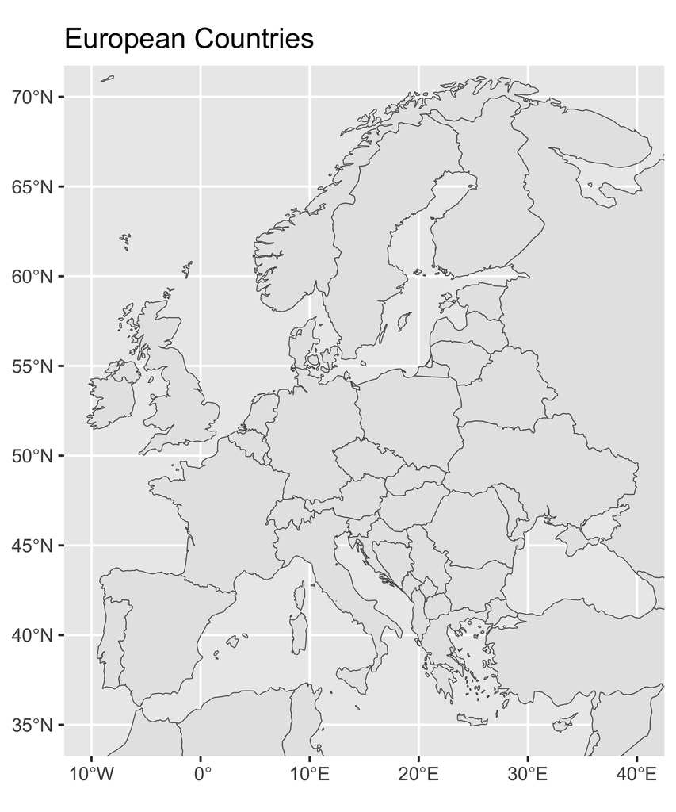

## Complex Geoms

### `geom_sf` Example

```r
europe_bounds <- list(x = c(-10, 40),
                      y = c(35, 70))

ggplot() +
  geom_sf(data = world) +
  coord_sf(xlim = europe_bounds$x,
           ylim = europe_bounds$y) +
  labs(title = "European Countries")
```

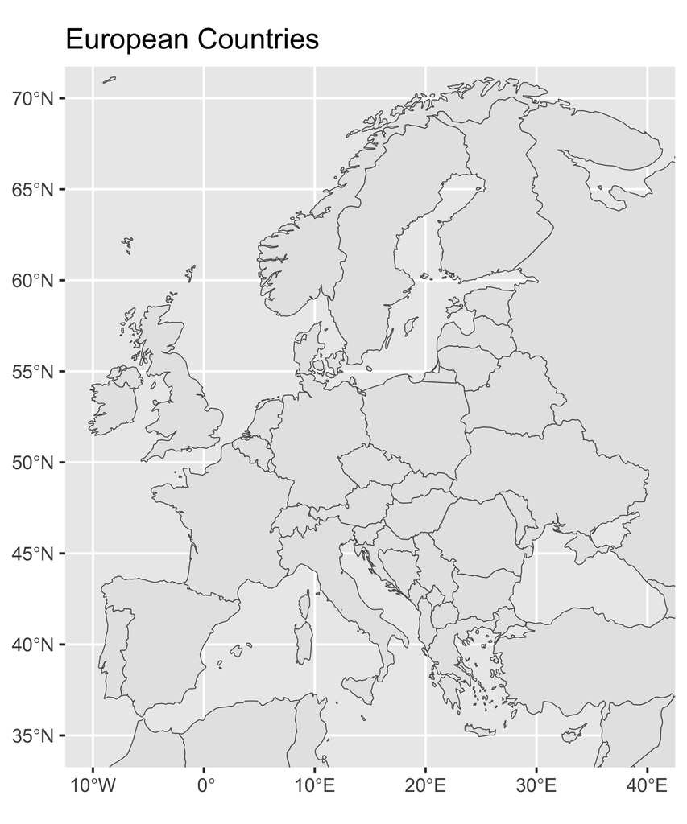

## Complex Geoms

### `geom_sf` Example

```r
europe_bounds <- list(x = c(-10, 40),
                      y = c(35, 70))

ggplot() +
  geom_sf(data = world) +
  coord_sf(xlim = europe_bounds$x,
           ylim = europe_bounds$y) +
  labs(title = "European Countries")
```

[figure not shown]

## Complex Geoms

### `geom_sf` Example

```r
europe_bounds <- list(x = c(-10, 40),
                      y = c(35, 70))

# Create a few points
cities <- data.frame(
  name = c("Rome", "Berlin", "Paris"),
  lon = c(12.5, 13.4, 2.35),
  lat = c(41.9, 52.5, 48.85)
)

# Convert to sf POINTs
cities_sf <- st_as_sf(cities, coords = c("lon", "lat"), crs = 4326)

# Mapping Them
ggplot() +
  geom_sf(data = world) +
  geom_sf(data = cities_sf) +
  coord_sf(xlim = europe_bounds$x,
           ylim = europe_bounds$y) +
  labs(title = "European Countries")
```

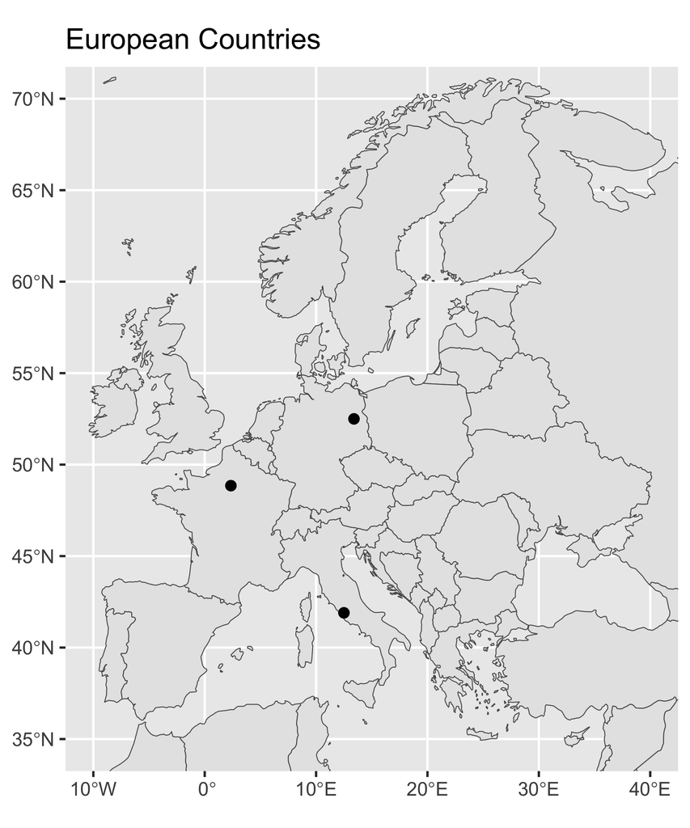

## Complex Geoms

### `geom_sf` Example

```r
europe_bounds <- list(x = c(-10, 40),
                      y = c(35, 70))

# Create a few points
cities <- data.frame(
  name = c("Rome", "Berlin", "Paris"),
  lon = c(12.5, 13.4, 2.35),
  lat = c(41.9, 52.5, 48.85)
)

# Convert to sf POINTs
cities_sf <- st_as_sf(cities, coords = c("lon", "lat"), crs = 4326)

# Create a line connecting Rome -> Berlin -> Paris
line_sf <- st_sfc(st_linestring(as.matrix(cities[, c("lon", "lat")])), crs = 4326)

# Mapping Them
ggplot() +
  geom_sf(data = world) +
  geom_sf(data = cities_sf) +
  geom_sf(data = line_sf) +
  coord_sf(xlim = europe_bounds$x,
           ylim = europe_bounds$y) +
  labs(title = "European Countries")
```

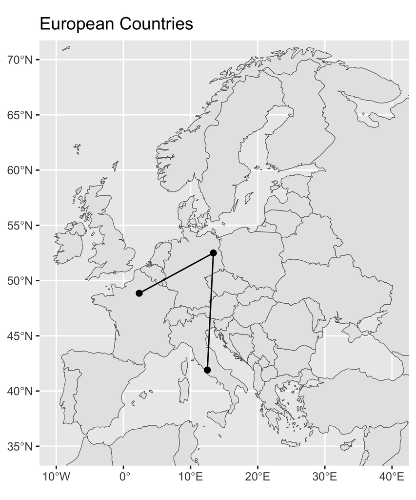

# Conclusion

## Key Takeaways

- **Grammar of Graphics**: Data + Aesthetics + Geoms = Visualization.
- **Simple geoms** (points, bars, lines, text) help explore relationships and categories.
- **Complex geoms** (histograms, density, boxplots, violins, maps) reveal deeper patterns.
- **Always tidy your data** before plotting.
- **Good visualization = clarity + accuracy**

# Exercises

## Exercises

### Points vs. Lines

Use the dataset below:

```r
df <- data.frame(
  year = c(2000, 2004, 2008, 2012, 2016, 2020),
  turnout = c(55, 58, 62, 60, 59, 65))
```

1. Make a scatterplot of turnout by year with `geom_point()`.
2. Now use geom_line().
3. Which geom makes more sense for these data? Why?

## Exercises

### Bar vs. Column

Suppose you have survey data on respondents’ education:

```r
df <- data.frame(
  education = c("Primary", "Primary", "High School", "High School", "College", "College", "College")
)
```

1. Plot the distribution of education levels with `geom_bar()`
2. Plot the distribution of education levels with `geom_col()`
3. What is the difference between the two approaches?

## Exercises

### Boxplot vs. Histogram

We surveyed trust in government on a 1–10 scale:

```r
set.seed(123)
df <- data.frame(
  trust = c(rnorm(30, mean = 5, sd = 2), rnorm(30, mean = 7, sd = 1))
)
```

1. Plot the distribution with a histogram.
2. Plot the same distribution with a boxplot.
3. What information is easier to see in the histogram? In the boxplot?

# Exercises Answers

## Exercises

### Points vs. Lines

Use the dataset below:

```r
df <- data.frame(
  year = c(2000, 2004, 2008, 2012, 2016, 2020),
  turnout = c(55, 58, 62, 60, 59, 65))
```

1. Make a scatterplot of turnout by year with `geom_point()`.

```r
library(ggplot2)
ggplot(df, aes(x = year, y=turnout)) +
  geom_point()
```

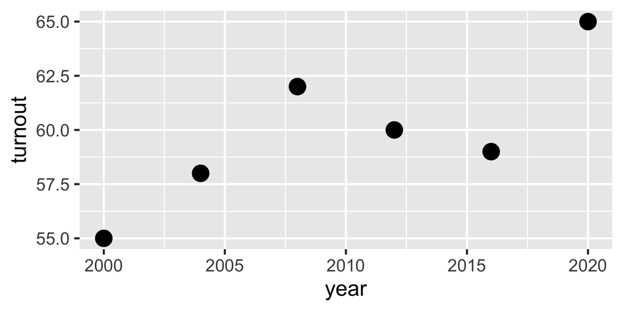

## Exercises

### Points vs. Lines

Use the dataset below:

```r
df <- data.frame(
  year = c(2000, 2004, 2008, 2012, 2016, 2020),
  turnout = c(55, 58, 62, 60, 59, 65))
```

2. Now use `geom_line()`.

```r
library(ggplot2)
ggplot(df, aes(x = year, y=turnout)) +
  geom_line()
```

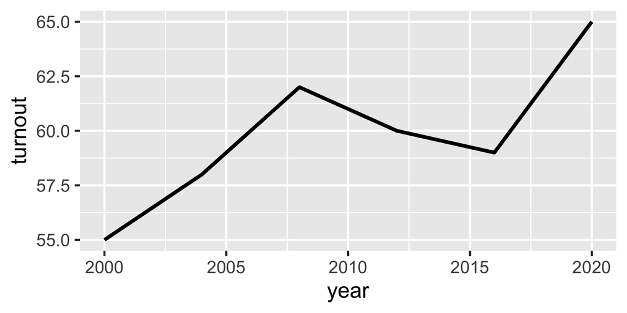

## Exercises

### Points vs. Lines

3. Which geom makes more sense for these data? Why?

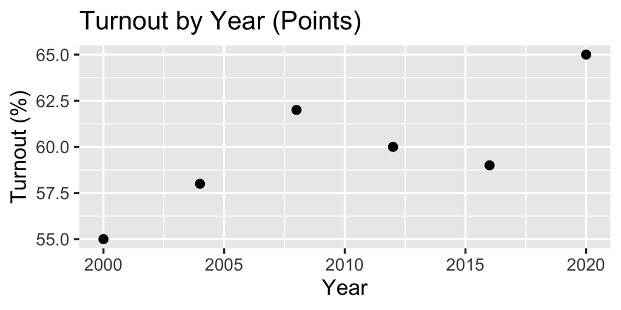

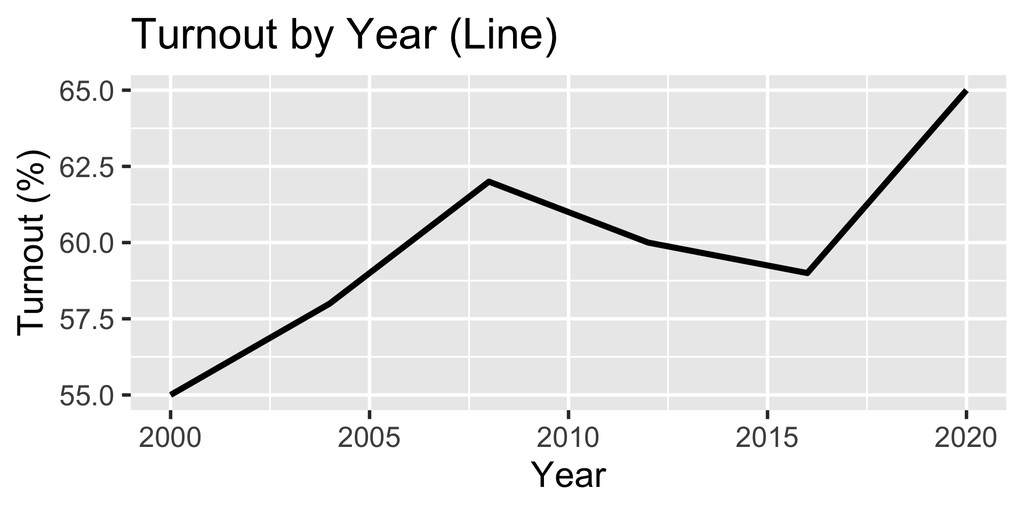

The line plot is usually more informative because it shows the trend in turnout over time.

## Exercises

### Bar vs. Column

Suppose you have survey data on respondents’ education:

```r
df <- data.frame(
  education = c("Primary", "Primary", "High School", "High School", "College", "College", "College")
)
```

1. Plot the distribution of education levels with `geom_bar()`

```r
# Bar plot
ggplot(df, aes(x = education)) +
  geom_bar()
```

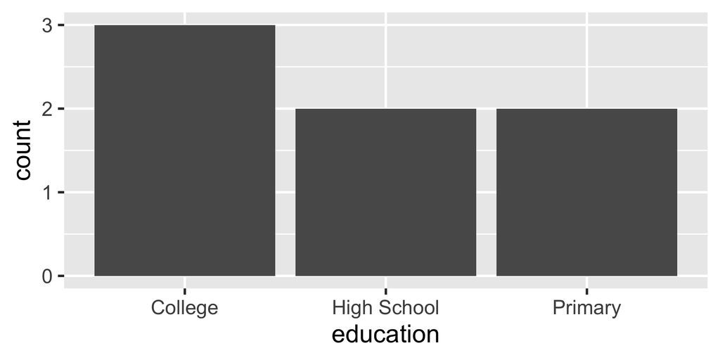

## Exercises

### Bar vs. Column

Suppose you have survey data on respondents’ education:

```r
df <- data.frame(
  education = c("Primary", "Primary", "High School", "High School", "College", "College", "College")
)
```

2. Pre-count the values with `dplyr::count()` and plot them with `geom_col()`:

```r
# Step1: Pre-count the values
df_counts <- df %>%
  count(education)
print(df_counts)
```

| education | n |
| --- | --- |
| College | 3 |
| High School | 2 |
| Primary | 2 |

## Exercises

### Bar vs. Column

Suppose you have survey data on respondents’ education:

```r
df <- data.frame(
  education = c("Primary", "Primary", "High School", "High School", "College", "College", "College")
)
```

2. Pre-count the values with `dplyr::count()` and plot them with `geom_col()`:

```r
# Step1: Pre-count the values
df_counts <- df %>%
  count(education)

# Step2: Plot with geom_col()
ggplot(df_counts, aes(x = education, y = n)) +
  geom_col()
```

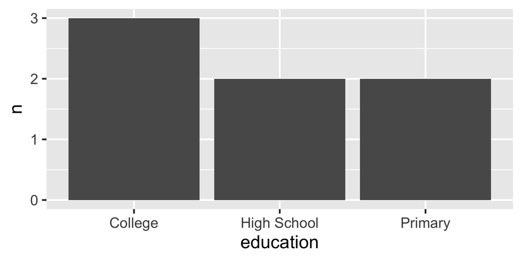

## Exercises

### Bar vs. Column

Suppose you have survey data on respondents’ education:

```r
df <- data.frame(
  education = c("Primary", "Primary", "High School", "High School", "College", "College", "College")
)
```

3. What is the difference between the two approaches?

The key distinction:

- `geom_bar()` = ggplot does the counting for you.
- `geom_col()` = you must provide the counts yourself.

## Exercises

### Boxplot vs. Histogram

We surveyed trust in government on a 1–10 scale:

```r
set.seed(123)
df <- data.frame(
  trust = c(rnorm(30, mean = 5, sd = 2), rnorm(30, mean = 7, sd = 1))
)
```

1. Plot the distribution with a histogram.

```r
# Histogram of trust
ggplot(df, aes(x = trust)) +
  geom_histogram(binwidth = 1, color = "white")
```

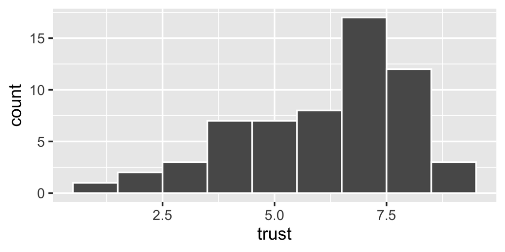

## Exercises

### Boxplot vs. Histogram

We surveyed trust in government on a 1–10 scale:

```r
set.seed(123)
df <- data.frame(
  trust = c(rnorm(30, mean = 5, sd = 2), rnorm(30, mean = 7, sd = 1))
)
```

2. Plot the same distribution with a boxplot.

```r
# Boxplot of trust
ggplot(df, aes(y = trust)) +
  geom_boxplot()
```

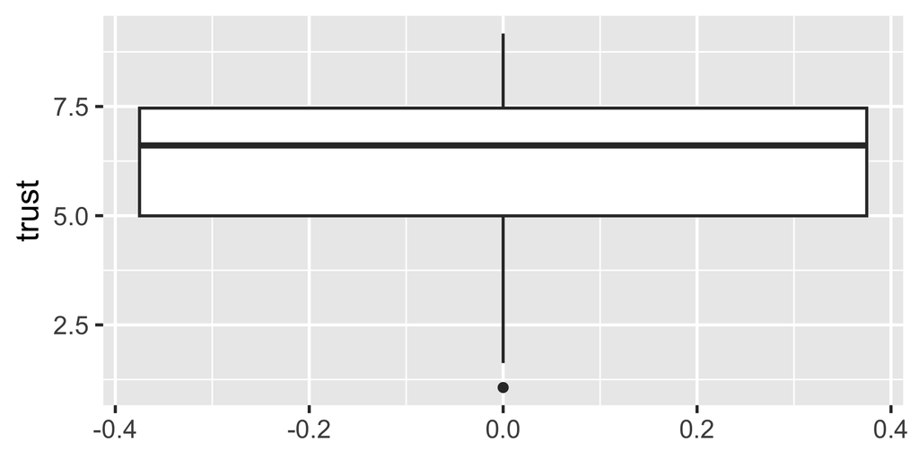

## Exercises

### Boxplot vs. Histogram

3. What information is easier to see in the histogram? In the boxplot?

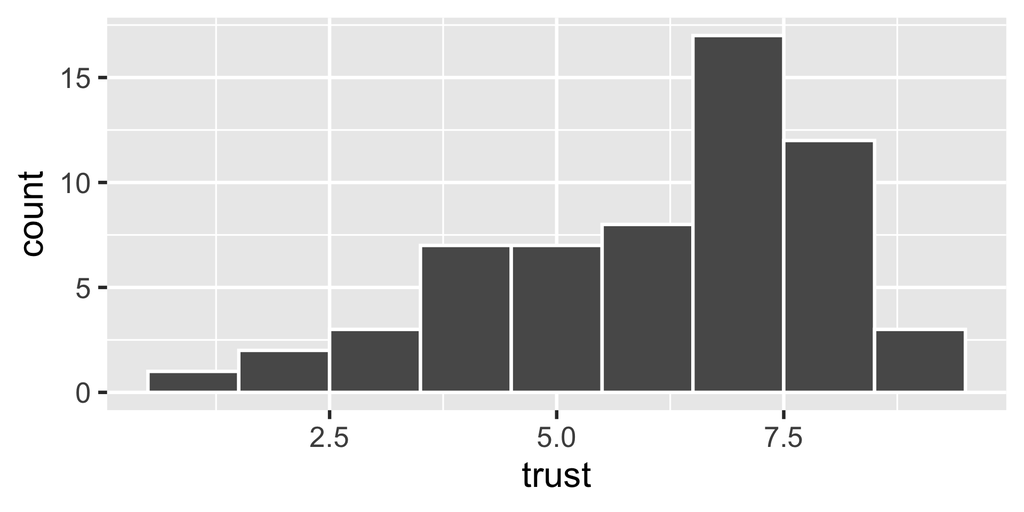

- Easier to see the shape of the distribution (is it unimodal, bimodal, skewed?).
- You can spot clusters (e.g., many respondents around 5 and many around 7).
- You get a sense of frequency across different ranges.

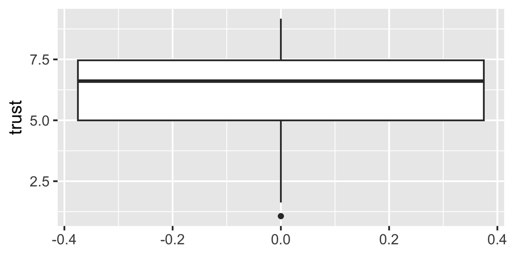

- Easier to see the median and spread at a glance.
- Shows quartiles (middle 50% of the data).
- Highlights outliers explicitly.